# Mental health: General population vs. tech workers

# Research questions

Which demographic factors are associated with higher risk of poor mental health, in the general population and in tech workers?

Do tech workers perceive that they have enough mental health support in the workplace?

# 1. National health survey: BRFSS

- Over 2 million responses from 2016 to 2020, ranging from 401,958 to 486,303 respondents per year
- Respondents were US residents who were 18+ years of age, living in private residences or college dorms, and sampled using telephone and cellphone sampling techniques

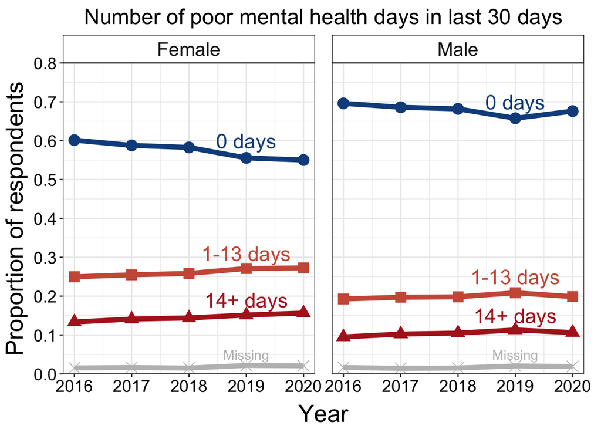

## Effect of time and sex on likelihood of poor mental health days

```r
> print(summary(m4))

Call:
svyglm(formula = ment14d_n ~ year_cent * sex_n, design = bdesign,
    family = quasibinomial(), data = c5b)

Survey design:
svydesign(id = ~psu, strata = ~ststr, nest = TRUE, weights = ~finalwt,
    data = c5b)

Coefficients:
                 Estimate Std. Error  t value Pr(>|t|)
(Intercept)     -0.806593   0.004634 -174.046  < 2e-16 ***
year_cent        0.029428   0.003319    8.867  < 2e-16 ***
sex_n            0.458826   0.006277   73.093  < 2e-16 ***
year_cent:sex_n  0.022925   0.004501    5.094 3.51e-07 ***
---
Signif. codes:  0 ‘***’ 0.001 ‘**’ 0.01 ‘*’ 0.05 ‘.’ 0.1 ‘ ’ 1

(Dispersion parameter for quasibinomial family taken to be 0.9999978)

Number of Fisher Scoring iterations: 4


> cbind(m4$coefficients, exp(cbind(OR = coef(m4), confint(m4))))
                                   OR     2.5 %    97.5 %
(Intercept)     -0.80659289 0.4463763 0.4423402 0.4504493
year_cent        0.02942772 1.0298650 1.0231877 1.0365859
sex_n            0.45882600 1.5822154 1.5628683 1.6018020
year_cent:sex_n  0.02292511 1.0231899 1.0142041 1.0322553
```

### Results interpretation

- The odds of having some poor mental health days have increased over time (about 3% increase/year)
- Being female is associated with 58% greater odds of having some poor mental health days, compared to being male
- Being female also means experiencing a steeper increase over time in the odds of having some poor mental health days (change in probability illustrated below)

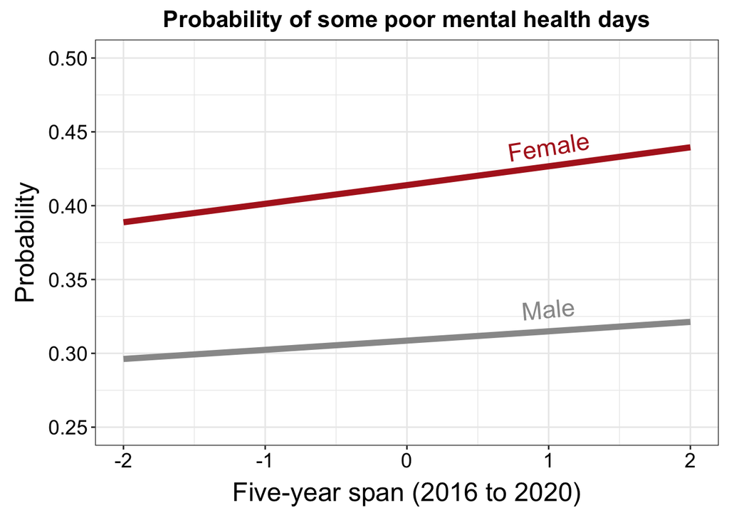

## Effect of other demographic variables

**Coding**  
* Age: Younger (18-44 y) = 1  
* Sex: Female = 1  
* Race: Non-white = 1  
* Education: College = 1  
* Annual household income: $75,000 and above = 1  
(Median household income in 2020 = 67,521)  
* Employment: employed/student/homemaker/retired = 1

```r
> summary(m3)

Call:
svyglm(formula = ment14d_n ~ ageg_n + sex_n + race_n + educag_n +
    income2_n + employ1_n, design = bdesign_c5b, family = quasibinomial(),
    data = c5b)

Survey design:
svydesign(id = ~psu, strata = ~ststr, nest = TRUE, weights = ~finalwt,
    data = c5b)

Coefficients:
             Estimate Std. Error t value Pr(>|t|)
(Intercept) -0.204011   0.011399 -17.898  < 2e-16 ***
ageg_n       0.770029   0.007284 105.715  < 2e-16 ***
sex_n        0.519475   0.007152  72.629  < 2e-16 ***
race_n      -0.311518   0.008489 -36.695  < 2e-16 ***
educag_n     0.036342   0.007567   4.803 1.57e-06 ***
income2_n   -0.183066   0.008226 -22.255  < 2e-16 ***
employ1_n   -0.917882   0.011453 -80.141  < 2e-16 ***
---
Signif. codes:  0 ‘***’ 0.001 ‘**’ 0.01 ‘*’ 0.05 ‘.’ 0.1 ‘ ’ 1

(Dispersion parameter for quasibinomial family taken to be 0.9996574)

Number of Fisher Scoring iterations: 4


> exp(cbind(OR = coef(m3), confint(m3)))
                   OR     2.5 %    97.5 %
(Intercept) 0.8154536 0.7974378 0.8338764
ageg_n      2.1598291 2.1292136 2.1908847
sex_n       1.6811442 1.6577414 1.7048774
race_n      0.7323342 0.7202497 0.7446214
educag_n    1.0370107 1.0217438 1.0525059
income2_n   0.8327129 0.8193953 0.8462469
employ1_n   0.3993640 0.3904988 0.4084304
```

### Results interpretation

- The biggest risk factor is being unemployed or unable to work, which increases the odds of poor mental health days by more than 2.5x compared to those who are employed, in school, retired, or homemakers
- The next biggest risk factor is age, with people under age 45 having >2x the odds of people 45+ of having some poor mental health days
- Taking into account other demographic variables, females have 68% greater odds compared to males
- Respondents who said their race was “non-white” had lower odds of poor mental health days; taking the inverse, it means that those who said their race was “white” had 37% greater odds

# 2. Tech worker survey: OSMI

- A total of 4398 responses collected from 2014 to 2020, skipping 2015
- Respondents were predominantly employed by tech companies or in a tech role (82%), based in the US (61%), and recruited via social media and from audiences at talks
- Note that only the 82% who said they were employed by a tech company or in a tech role are included in the regression models

## Number of survey questions and respondents by year

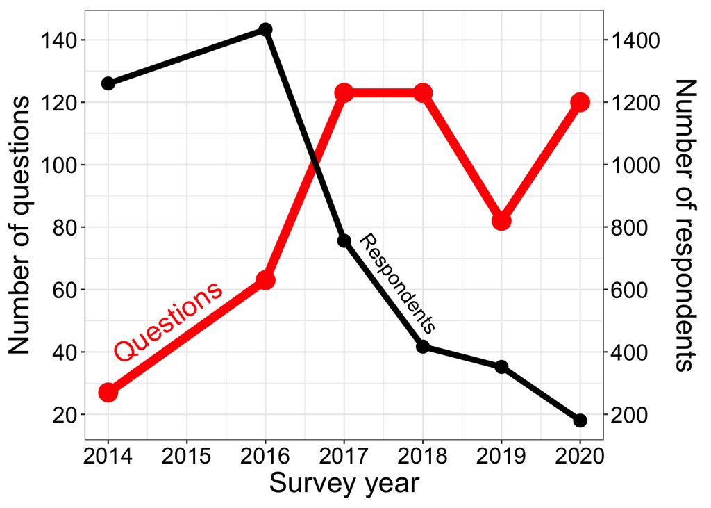

## Demographics

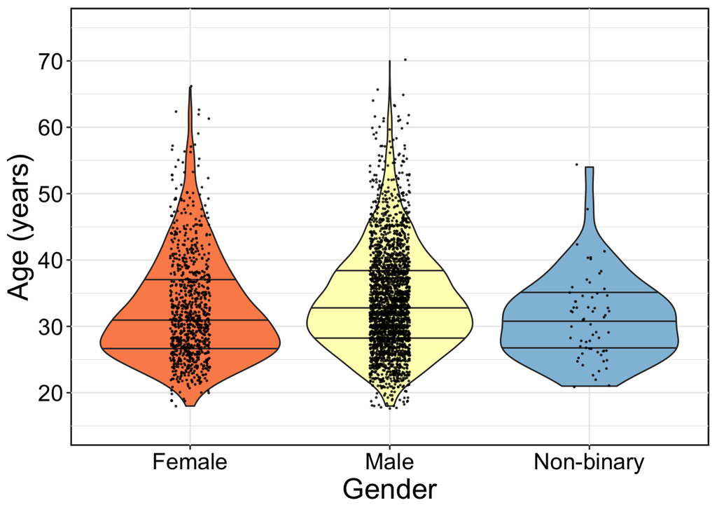

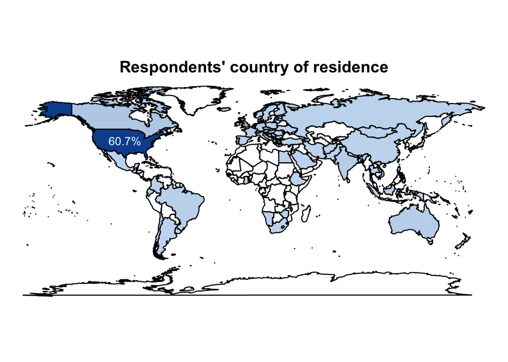

## Effect of time and gender on likelihood of current disorder

**Coding**  
* Year: continuous  
* Gender: Female = 1

```
##
## Call:
## glm(formula = current_disorder_n ~ year_z * gender_n, family = c("binomial"),
##     data = cc)
##
## Deviance Residuals:
##    Min      1Q  Median      3Q     Max
## -1.496  -1.154   0.889   1.162   1.240
##
## Coefficients:
##                 Estimate Std. Error z value Pr(>|z|)
## (Intercept)     -0.05327    0.05585  -0.954   0.3402
## year_z           0.11029    0.05599   1.970   0.0489 *
## gender_n         0.76964    0.10774   7.144 9.09e-13 ***
## year_z:gender_n -0.11970    0.10753  -1.113   0.2656
## ---
## Signif. codes:  0 '***' 0.001 '**' 0.01 '*' 0.05 '.' 0.1 ' ' 1
##
## (Dispersion parameter for binomial family taken to be 1)
##
##     Null deviance: 2522.2  on 1827  degrees of freedom
## Residual deviance: 2464.4  on 1824  degrees of freedom
## AIC: 2472.4
##
## Number of Fisher Scoring iterations: 4
```

```
##                 OddsRatio     2.5 %   97.5 %
## (Intercept)     0.9481264 0.8497507 1.057797
## year_z          1.1166001 1.0007232 1.246548
## gender_n        2.1589835 1.7502827 2.670559
## year_z:gender_n 0.8871867 0.7191554 1.096655
```

### Results interpretation

- In this self-selected sample, the odds of reporting a current mental health disorder generally increase by 11.7% per year
- Similar to the population health survey, females in this sample are more likely than males to report a current mental health disorder
- There is no evidence of a difference between males and females in the change in odds over time
- Note that the steep decrease in sample size over time may have affected data quality

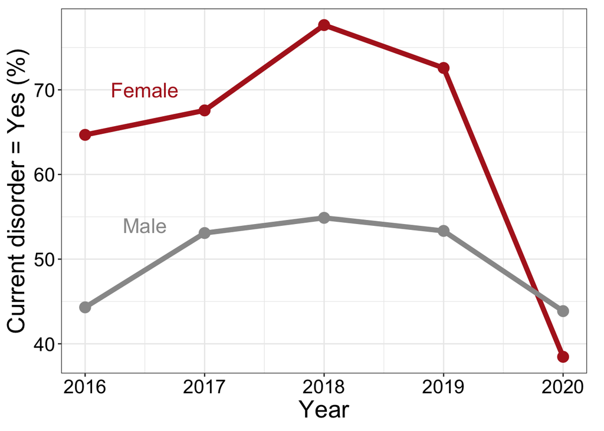

## Effect of other demographic variables

**Coding**  
* Age: continuous  
* Gender: Female = 1, Males = 0  
* Country: US = 1, All other = 0

```
##
## Call:
## glm(formula = current_disorder_n ~ age + gender_n + country_n,
##     family = c("binomial"), data = cc)
##
## Deviance Residuals:
##     Min       1Q   Median       3Q      Max
## -1.6481  -1.2268   0.7888   1.0516   1.5602
##
## Coefficients:
##              Estimate Std. Error z value Pr(>|z|)
## (Intercept) -0.443709   0.224205  -1.979   0.0478 *
## age         -0.006597   0.006128  -1.077   0.2817
## gender_n     0.658345   0.110430   5.962  2.5e-09 ***
## country_n    0.971453   0.104565   9.290  < 2e-16 ***
## ---
## Signif. codes:  0 '***' 0.001 '**' 0.01 '*' 0.05 '.' 0.1 ' ' 1
##
## (Dispersion parameter for binomial family taken to be 1)
##
##     Null deviance: 2520.6  on 1826  degrees of freedom
## Residual deviance: 2378.1  on 1823  degrees of freedom
##   (1 observation deleted due to missingness)
## AIC: 2386.1
##
## Number of Fisher Scoring iterations: 4
```

```
##             OddsRatio     2.5 %    97.5 %
## (Intercept) 0.6416523 0.4127648 0.9944976
## age         0.9934247 0.9815622 1.0054423
## gender_n    1.9315937 1.5573469 2.4014010
## country_n   2.6417800 2.1540218 3.2457627
```

### Results interpretation

- Unlike in the population health survey, there is no clear effect of age on the odds of having a current mental health disorder (but note that the age distribution is more narrow in this sample)
- Like in the population survey, females experience a bigger risk than males
- The biggest risk factor appears to be respondents’ country of residence, where living in the US means 2.6x the odds of reporting a current mental health disorder compared to living in other countries

## Workplace support

### Does your employer provide mental health benefits as part of healthcare coverage?

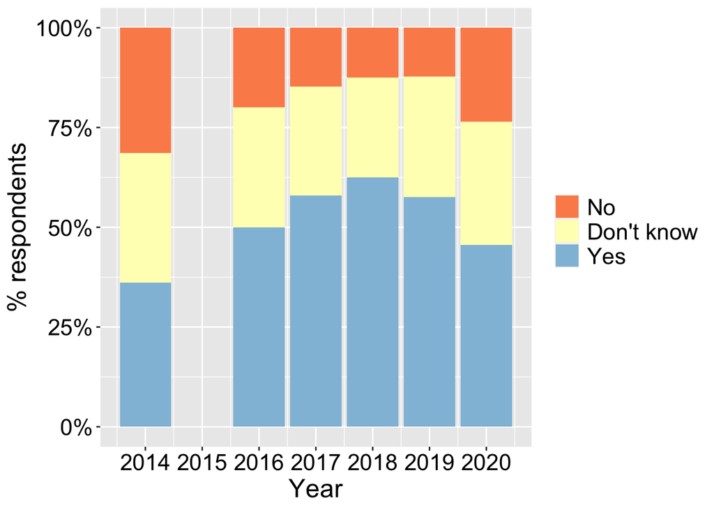

### Does your employer offer resources to learn more about mental health disorders and options for seeking help?

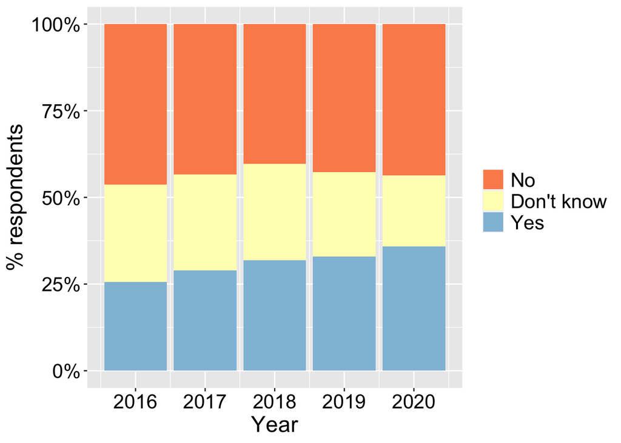

### How well do you think the tech industry supports employees with mental health issues?

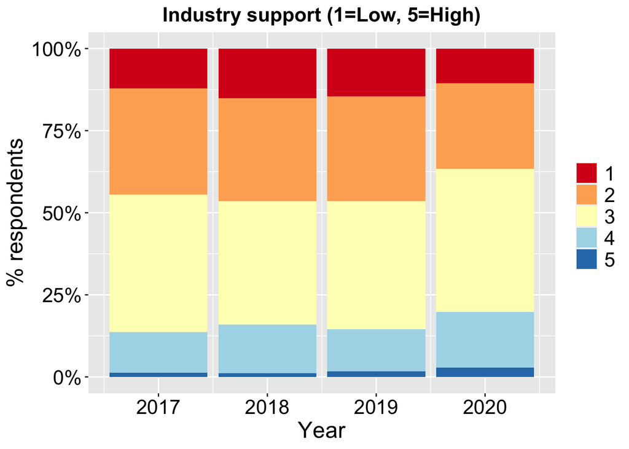

## Workplace openness to discussion

About half of respondents (55.8%) feel equally comfortable or uncomfortable discussing a mental health issue with their peers or their boss. The remaining respondents are split between those who are more comfortable with their peers (20.2%), and those who are more comfortable with their boss (23.9%).

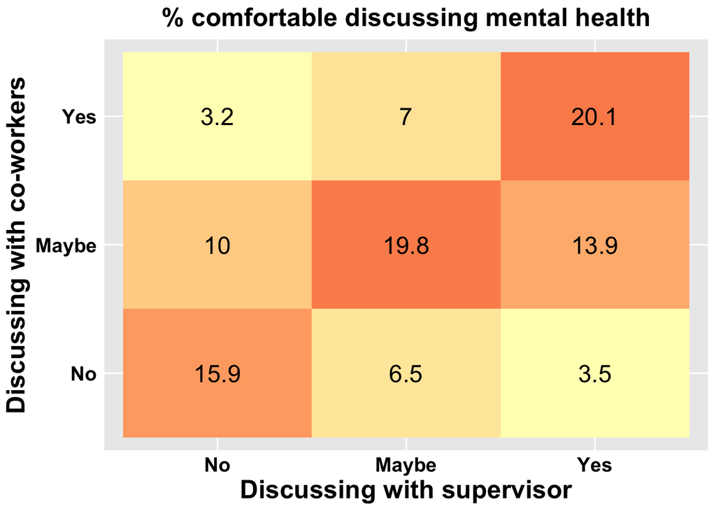

# Conclusions

Mental health appears to be getting slightly **worse over time**, according to the trend in a large representative sample. **Being female** is a risk factor for poorer mental health, in both the general population and in tech workers. Further research is needed to find out why.

About **half** of tech workers have healthcare benefits that provide options for mental health treatment. A large portion of the remaining respondents don’t know if they have such benefits, so raising awareness about existing benefits is an easy first thing to do (e.g. by making the documentation clearer on employee websites).

**Less than half** of tech workers are comfortable discussing a mental health issue with someone at work, either a co-worker or supervisor, which means that some people may be struggling without others knowing.

**Less than 1 in 4** workers think that their industry is giving them good mental health support. The next step could be to find out what kind of support they need (e.g. supplying mental healthcare benefits to those who don’t have them, or structuring one-on-ones to include a well-being check as well as productivity or work progress).